# Gradient_Descent

### Gradient Descent Implementation in Python

Hello guys, now we are within the Jypyter Notebook, welcome! Here we are going to make our own implementation of gradient descent in Python, so buckle in. First we create a data set, i.e. x and y variables:

```python
import numpy as np
x = np.array([1, 2, 3, 4, 5])
y = np.array([3, 6, 9, 12, 15])
```

We can plot y vs. x and observe the linear dependence:

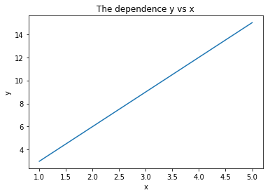

```python
import matplotlib.pyplot as plt
plt.plot(x,y)
plt.xlabel('x')
plt.ylabel('y')
plt.title('The dependence y vs x')
plt.show()
```

Thus we have a linear regression model: $$y = \alpha + \beta x + \epsilon$$

assuming the residuals to follow normal distribution, maximization of the Likelihood of observing the data is equivalent to minimization of residuals in the Ordinary Least Squares fassion:

$$\epsilon = \frac{1}{N}\sum_i{(y_i - \alpha - \beta x_i)^2}$$

where $N$ is the number of observations. We are going to minimize the residual error via Gradient Descent according to the following recursive rules:

$$\alpha_{n+1} = \alpha_n - \mu\frac{\partial\epsilon}{\partial\alpha}$$$$\beta_{n+1} = \beta_n - \mu\frac{\partial\epsilon}{\partial\beta}$$

where $\mu$ is called "the learning rate" and determines the speed of approaching the minimum/maximum when performing optimization. The derivatives are given by:

$$\frac{\partial\epsilon}{\partial\alpha}=-\frac{2}{N}\sum_i(y_i-\alpha-\beta x_i)$$$$\frac{\partial\epsilon}{\partial\beta}=-\frac{2}{N}\sum_i x_i(y_i-\alpha-\beta x_i)$$

Next we are going to perform the recursion and therefore need to randomly initialize the $\alpha$ and $\beta$ variables:

```python
N = x.size
np.random.seed(0)
alpha_init = np.random.randn()
print(alpha_init)
beta_init = np.random.randn()
print(beta_init)
```

```
1.764052345967664
0.4001572083672233
```

Now let us perform Gradient Descent minimization of the residual error function:

```python
N_iter = 10000
alpha = np.empty(N_iter+1)
alpha[0] = alpha_init
beta = np.empty(N_iter+1)
beta[0] = beta_init
err = []
mu = 0.01
for i in range(N_iter):
    derr_dalpha = -2*np.sum(y - alpha[i] - beta[i]*x)/N
    derr_dbeta = -2*np.sum(x*(y - alpha[i] - beta[i]*x))/N
    err.append(np.sum((y - alpha[i] - beta[i]*x)**2))
    alpha[i+1] = alpha[i] - mu*derr_dalpha
    beta[i+1] = beta[i] - mu*derr_dbeta
for a,b in zip(range(0,N_iter,1000),range(0,N_iter,1000)):
    print('alpha = ' + str(alpha[a]), 'beta = ' + str(beta[b]))
print('\n')
print('Final alpha = ' + str(alpha[N_iter]))
print('Final beta = ' + str(beta[N_iter]))
```

```
alpha = 1.764052345967664 beta = 0.4001572083672233
alpha = 0.07802917174037734 beta = 2.978387170629708
alpha = 0.002638979482422354 beta = 2.999269044999541
alpha = 8.925139859062759e-05 beta = 2.9999752787937415
alpha = 3.0185199259516726e-06 beta = 2.9999991639183823
alpha = 1.0208761667626754e-07 beta = 2.999999971723367
alpha = 3.452646763686521e-09 beta = 2.999999999043672
alpha = 1.1676940089979057e-10 beta = 2.999999999967657
alpha = 3.9519512952274775e-12 beta = 2.9999999999989053
alpha = 1.3512177611758813e-13 beta = 2.9999999999999623


Final alpha = 1.74772153577884e-14
Final beta = 2.9999999999999942
```

The error seems to be decreasing which is good!

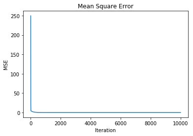

```python
plt.plot([x for x in range(N_iter)],err)
plt.xlabel('Iteration')
plt.ylabel('MSE')
plt.title('Mean Square Error')
plt.show()
```

Finally, let us compare the $\alpha$ and $\beta$ coefficients with the one obtained in R and make sure that they are similar:

```python
import rpy2.ipython
%load_ext rpy2.ipython
```

```python
%%R
x<-c(1, 2, 3, 4, 5)
y<-c(3, 6, 9, 12, 15)
summary(lm(y~x))
```

```
Call:
lm(formula = y ~ x)

Residuals:
         1          2          3          4          5
 2.807e-15 -3.179e-15 -8.695e-16  5.019e-17  1.192e-15

Coefficients:
             Estimate Std. Error   t value Pr(>|t|)
(Intercept) 3.178e-15  2.719e-15 1.169e+00    0.327
x           3.000e+00  8.199e-16 3.659e+15   <2e-16 ***
---
Signif. codes:  0 ‘***’ 0.001 ‘**’ 0.01 ‘*’ 0.05 ‘.’ 0.1 ‘ ’ 1

Residual standard error: 2.593e-15 on 3 degrees of freedom
Multiple R-squared:      1,	Adjusted R-squared:      1
F-statistic: 1.339e+31 on 1 and 3 DF,  p-value: < 2.2e-16
```

Excellent, Gradient Descent seems to work, the mission is complete now, time to go to bed because tomorrow my youngest boy is going to wake up at 6 am. Good night!